# An Analysis of Obesity Prevelance in Scotland from 2013 to 2016

Author

Group 1

# 1 Introduction

In the past few years, obesity has become a major public health problem worldwide, and obesity can induce a series of chronic diseases and conditions. Obesity occurs when an individual’s energy intake from food and drink is higher than the amount of energy needed over a period of time. Exploring factors that influence obesity can help to develop effective intervention measures to reduce the number of obese people and reduce the impact on public health.

Data for this report has been gathered from the Scottish Health Surveys from 2013-2016. The data includes the binary variable, `Obese`, which indicates whether an individual classes themselves as obese (Yes), or not obese (No), and the following other lifestyle and socio-economic factors:

- `AgeGroup` - The age range of the individual (a categorical variable with seven different age categories).
- `Sex` - The sex of an individual (a binary variable with categories Male or Female).
- `Employment` - The individual’s employment status (a categorical variable with seven different employment categories).
- `Veg` - Indicates whether the individual consumes the recommended daily intake of vegetables (a binary variable with categories Yes or No).
- `Fruit` - Indicates whether the individual consumes the recommended daily intake of fruit (a binary variable with categories Yes or No).
- `Year` - The year in which the Scottish Health Survey was conducted (a categorical variable with categories corresponding to years 2013, 2014, 2015 and 2016).

The main focus of this report will be to examine the prevalence of obesity in Scotland over the given years and to examine differences in obesity by age, sex and the other lifestyle and socio-economic factors.

Section 2 consists of an exploratory analysis of the obesity data and explores the potential relationship between factors. Section 3 contains the results from fitting a logistic regression model to the data, as well as the assessment of the model assumptions. Concluding remarks are given in Section 4.

# 2 Exploratory Analysis

Figure 1 displays the relationship between variables `Obesity` and `Year` revealing the prevalence of obesity in Scotland over the given years of the Scottish Health Survey. From Figure 1, we can see that, on average, there was not much change in the recorded number of obese individuals in Scotland by year from 2013 to 2016. We observe a slightly smaller count in 2016 compared to the previous three years, but it appears that `Year` is not a significant explanatory variable.

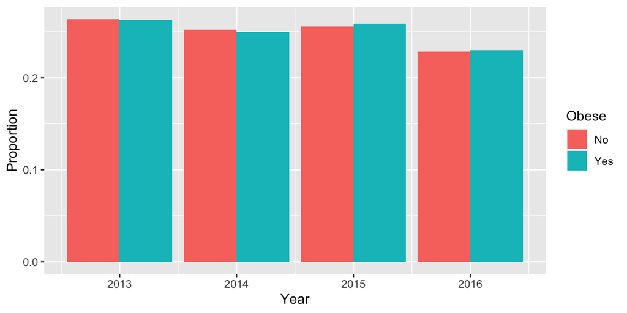

Figure 1: Relationship between Obesity and Year.

In Figure 2 we observe the relationships between `Obesity` and `AgeGroup`, and `Obesity` and `Sex`. It is revealed that the obesity proportion is highest in the 55-64 age group and decreases as age decreases, as well as for an increase in age. The lowest obesity proportion is counted in the 16-24 age group.

We can also see in Figure 2 that obesity appears slightly higher in females than in males. But within the categories we observe that more females are obese than not obese, while the opposite is true for males.

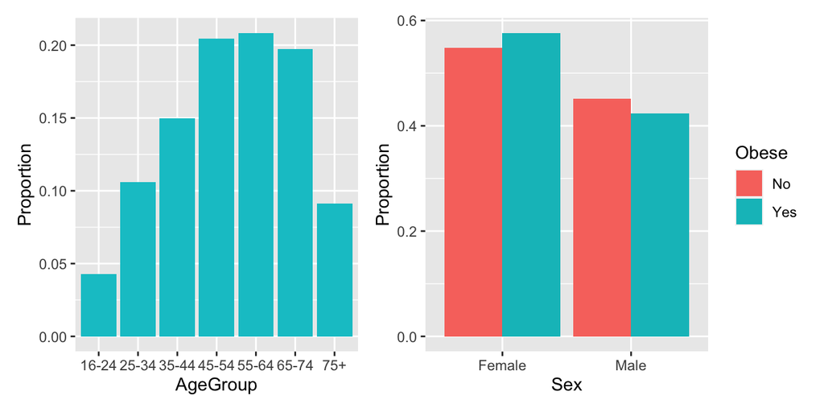

Figure 2: Obesity by Age Group and Sex.

We also observe the relationship between `Obesity` and different lifestyle factors (whether or not the individual consumes the recommended daily intake of fruit or vegetables) in Figure 3. Obesity seems to be more prevalent in those who did consume the recommended daily intake of fruit or veg compared to those who didn’t. However, there is little to no difference between the proportion of obese people and not obese people, so these variables (`Fruit` in particular) seem insignificant at this stage.

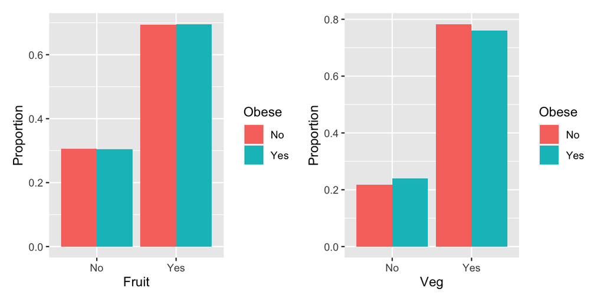

Figure 3: Relationship between Obesity and Lifestyle Factors.

The relationship between `Obesity` and `Employment` is revealed in Figure 4. The obesity proportion is clearly highest in employed individuals, followed by retirees, while the other factors appear to have very low proportions of obesity.

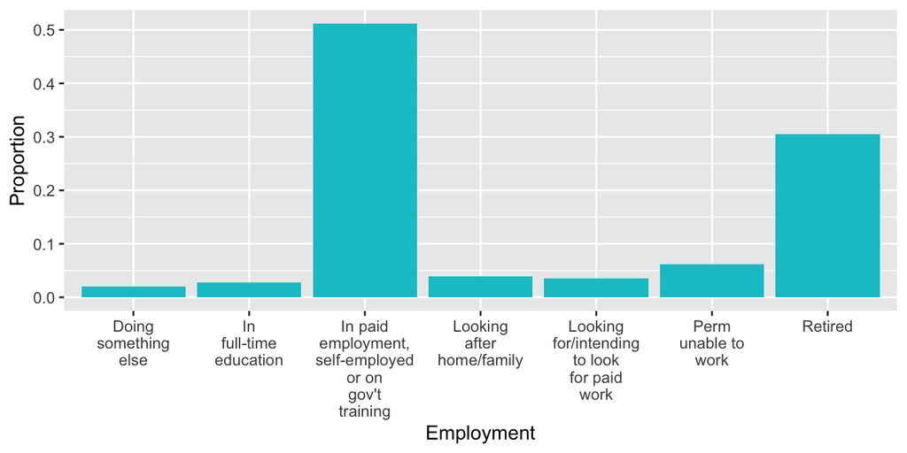

Figure 4: Relationship between Obesity and Socio-economic Status.

Finally, Figure 5 is plotted to see if there is any relationship between `AgeGroup` and `Sex`. Initial inspection of Figure 5 highlights that there does seem to be some difference between proportions of `Sex` by `AgeGroup` between some of the age groups, so we may want to fit the interaction between these variables in our model.

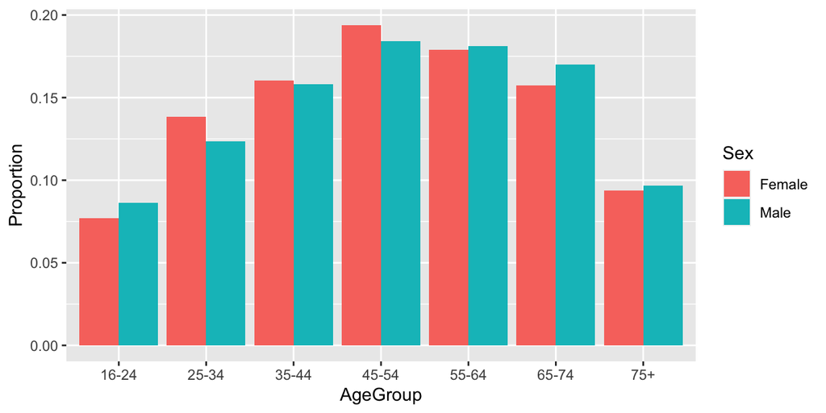

Figure 5: Relationship between Age and Sex.

# 3 Formal Analysis

To analyse the prevalence of obesity over the given years, we produce a logistic regression model for `Obesity` by `Year`. The large p-values shown in Figure 6 match our assumptions from Figure 1: we can conclude that year has no statistically significant effect on obesity in Scotland.

|  | Estimate | Std. Error | z value | Pr(>\|z\|) |
| --- | --- | --- | --- | --- |
| (Intercept) | -0.8330257 | 0.0358072 | -23.2642066 | 0.0000000 |
| Year2014 | -0.0056340 | 0.0512792 | -0.1098688 | 0.9125134 |
| Year2015 | 0.0162645 | 0.0508975 | 0.3195548 | 0.7493058 |
| Year2016 | 0.0111467 | 0.0524656 | 0.2124565 | 0.8317509 |

Figure 6: Summary of GLM outputs with Year as explanatory variable.

Now we go ahead and fit a model in order to analyse the relationship between obesity and our other variables. The `Year` and `Fruit` variables are not included in our initial fit of the model: our exploratory analysis revealed that these variables do not appear to impact obesity. Also, there does not appear to be any interaction between an individual’s sex and their employment status, so we remove this interaction from the final model. The `StepAIC` function from the `MASS` package is then used to fit the model with the lowest AIC, the output of which is displayed in Figure 7.

Since the baseline category for our response (`Obese`) is “No”, the estimates from our fitted logistic regression model are for changes in the log-odds for individuals that answered “Yes” to the obesity self-evaluation compared with the log-odds of those who answered “No”.

|  | Estimate | Std. Error | z value | Pr(>\|z\|) | Lower.Bound | Upper.Bound |
| --- | --- | --- | --- | --- | --- | --- |
| (Intercept) | -1.2235057 | 0.1738140 | -7.0391675 | 0.0000000 | -1.5641811 | -0.8828303 |
| VegYes | -0.1654043 | 0.0444574 | -3.7205096 | 0.0001988 | -0.2525409 | -0.0782677 |
| SexMale | -0.5692815 | 0.1690166 | -3.3681993 | 0.0007566 | -0.9005539 | -0.2380090 |
| EmploymentIn full-time education | -0.2906684 | 0.1746231 | -1.6645479 | 0.0960030 | -0.6329297 | 0.0515928 |
| EmploymentIn paid employment, self-employed or on gov’t training | -0.0315053 | 0.1341119 | -0.2349182 | 0.8142723 | -0.2943647 | 0.2313541 |
| EmploymentLooking after home/family | 0.3753494 | 0.1652890 | 2.2708674 | 0.0231550 | 0.0513830 | 0.6993159 |
| EmploymentLooking for/intending to look for paid work | 0.2481246 | 0.1661824 | 1.4930859 | 0.1354147 | -0.0775929 | 0.5738420 |
| EmploymentPerm unable to work | 0.4425461 | 0.1550018 | 2.8551023 | 0.0043023 | 0.1387425 | 0.7463497 |
| EmploymentRetired | 0.0492760 | 0.1475305 | 0.3340053 | 0.7383756 | -0.2398838 | 0.3384358 |
| AgeGroup25-34 | 0.3078846 | 0.1300082 | 2.3681932 | 0.0178752 | 0.0530685 | 0.5627007 |
| AgeGroup35-44 | 0.5110762 | 0.1272830 | 4.0152735 | 0.0000594 | 0.2616015 | 0.7605510 |
| AgeGroup45-54 | 0.6320838 | 0.1249245 | 5.0597261 | 0.0000004 | 0.3872318 | 0.8769359 |
| AgeGroup55-64 | 0.6181911 | 0.1281306 | 4.8246967 | 0.0000014 | 0.3670552 | 0.8693270 |
| AgeGroup65-74 | 0.7747508 | 0.1438577 | 5.3855361 | 0.0000001 | 0.4927897 | 1.0567119 |
| AgeGroup75+ | 0.5615485 | 0.1563394 | 3.5918562 | 0.0003283 | 0.2551234 | 0.8679737 |
| SexMale:AgeGroup25-34 | 0.3122112 | 0.2026095 | 1.5409504 | 0.1233289 | -0.0849034 | 0.7093258 |
| SexMale:AgeGroup35-44 | 0.3481537 | 0.1939381 | 1.7951794 | 0.0726251 | -0.0319650 | 0.7282725 |
| SexMale:AgeGroup45-54 | 0.4999260 | 0.1885342 | 2.6516455 | 0.0080101 | 0.1303989 | 0.8694531 |
| SexMale:AgeGroup55-64 | 0.7277964 | 0.1888479 | 3.8538772 | 0.0001163 | 0.3576547 | 1.0979382 |
| SexMale:AgeGroup65-74 | 0.5708148 | 0.1901281 | 3.0022645 | 0.0026798 | 0.1981638 | 0.9434659 |
| SexMale:AgeGroup75+ | 0.2372185 | 0.2088176 | 1.1360084 | 0.2559531 | -0.1720639 | 0.6465009 |

Figure 7: Summary of GLM outputs for the final model.

In order to examine ranges of plausible log-odds of obesity for each of the predictors in the fitted model equation, we can observe the 95% confidence interval bounds given in Figure 7 . Note that these confidence intervals also highlight significance of the parameters, which solidify the conclusions reached from the p-values in Figure 7.

Figure 7 shows the 95% confidence intervals for each regression parameter included in the fitted model. For example, we are 95% confident that the log-odds of an individual being obese is, on average, 0.078 to 0.252 lower if the individual eats vegetables.

## 3.1 Assessing model assumptions

Our model is a logistic regression so the assumptions made for this model are that we have constant variance and the errors are independent of one another. The assumption of independence is already met as the individuals from our data set are independent of one another. Additionally, the assumption is made that our model does not have any influential observations which may alter the quality of our model. To check this we will first visualise the values of Cook’s Distance.

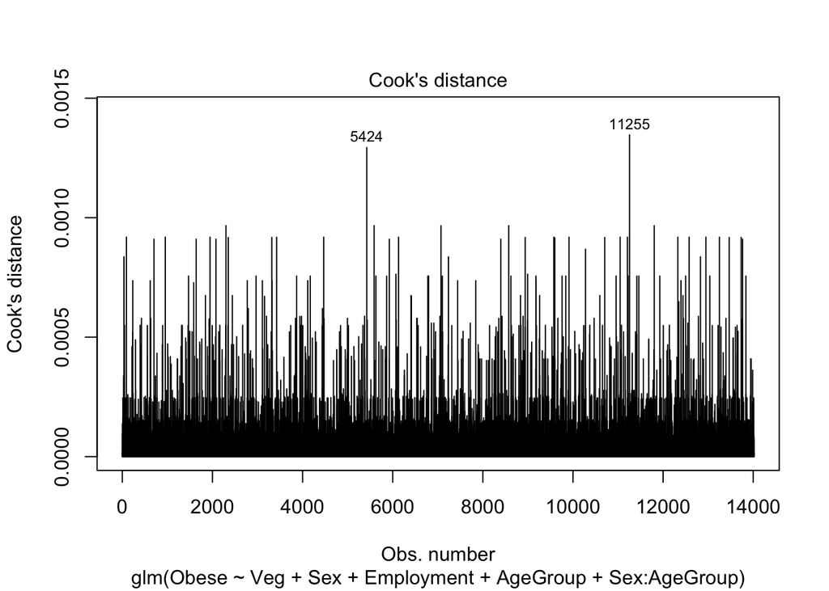

Figure 8: Cook’s distance plot with 2 largest values labeled.

From Figure 8 it can be seen there are two clear outliers but this does not necessarily indicate that they are influential. Now we will plot the standardised residuals of the model to see if these outliers deserve further attention.

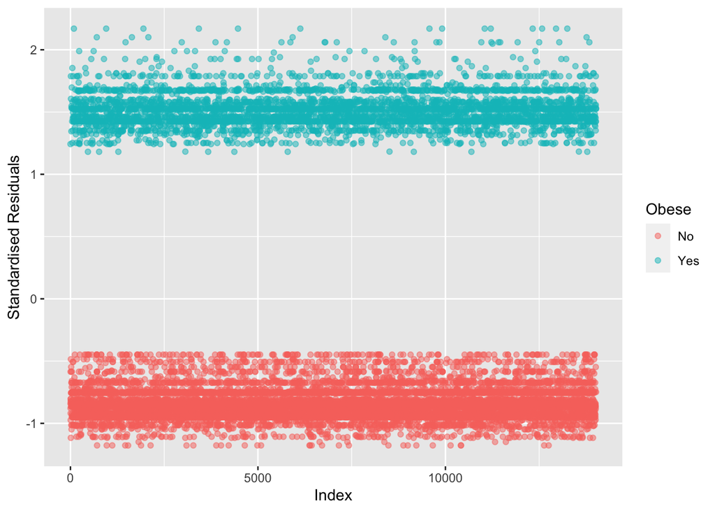

Figure 9: Plot of Standardised Residuals.

It can be seen from Figure 9 that the absolute values of our standardised residuals do not exceed 3, hence there are no influential observations within our data. Clearly from the plot of standardised residuals there are no patterns, which further indicates that the errors for our model are independent. Additionally, it can be seen that the spread of these residuals is constant and therefore the assumption of constant variance holds.

# 4 Conclusion

Obesity prevalence has shown little change between 2013 and 2016. Obesity was found to differ by sex, age, and socio-economic and lifestyle factors. In particular, we found that obesity was less common in those who consumed the recommended daily intake of vegetables, but the consumption of fruit by an individual was not a significant predictor for obesity.

In terms of socio-economic factors, we can see that there was an increase of 1.56 in the odds of evaluating as obese among those permanently unable to work compared to those “doing something else”. These odds are the highest among all employment-statuses given.

## 4.1 References

- [https://www.obesityactionscotland.org/media/235lfdxq/prevalence_causes__](https://www.obesityactionscotland.org/media/235lfdxq/prevalence_causes__impact_1920_data_f_2023_updated_version.pdf)

  impact_1920_data_f_2023_updated_version.pdf